# another experiment

Evangeline Reynolds

2026-07-28

> The data given by x are clustered by the k-means method, which aims to partition the points into k groups such that the sum of squares from points to the assigned cluster centres is minimized. At the minimum, all cluster centres are at the mean of their Voronoi sets (the set of data points which are nearest to the cluster centre).

> The algorithm of Hartigan and Wong (1979) is used by default. Note that some authors use k-means to refer to a specific algorithm rather than the general method: most commonly the algorithm given by MacQueen (1967) but sometimes that given by Lloyd (1957) and Forgy (1965). The Hartigan–Wong algorithm generally does a better job than either of those, but trying several random starts (nstart > 1) is often recommended. In rare cases, when some of the points (rows of x) are extremely close, the algorithm may not converge in the “Quick-Transfer” stage, signalling a warning (and returning ifault = 4). Slight rounding of the data may be advisable in that case.

> For ease of programmatic exploration, k=1 is allowed, notably returning the center and withinss.

> Except for the Lloyd–Forgy method, k clusters will always be returned if a number is specified. If an initial matrix of centres is supplied, it is possible that no point will be closest to one or more centres, which is currently an error for the Hartigan–Wong method.

[figure not shown]

## Status Quo, without ggkmeans

> https://www.tidymodels.org/learn/statistics/k-means/index.html#exploratory-clustering

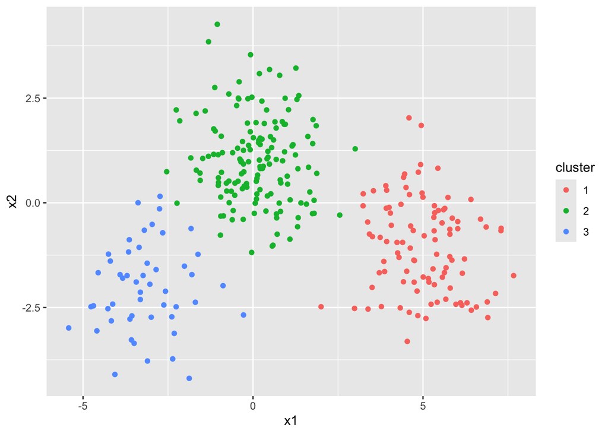

```r
library(tidyverse)

library(tidymodels)

set.seed(27)

centers <- tibble(
  cluster = factor(1:3),
  num_points = c(100, 150, 50),  # number points in each cluster
  x1 = c(5, 0, -3),              # x1 coordinate of cluster center
  x2 = c(-1, 1, -2)              # x2 coordinate of cluster center
)

labelled_points <-
  centers %>%
  mutate(
    x1 = map2(num_points, x1, rnorm),
    x2 = map2(num_points, x2, rnorm)
  ) %>%
  select(-num_points) %>%
  unnest(cols = c(x1, x2))

ggplot(labelled_points) +
  aes(x1,
      x2,
      color = cluster) +
  geom_point()
```

```r
points <-
  labelled_points %>%
  select(-cluster)

kclust <- kmeans(points, centers = 3)
kclust
```

```
## K-means clustering with 3 clusters of sizes 148, 51, 101
##
## Cluster means:
##            x1        x2
## 1  0.08853475  1.045461
## 2 -3.14292460 -2.000043
## 3  5.00401249 -1.045811
##
## Clustering vector:
##   [1] 3 3 3 3 3 3 3 3 3 3 3 3 3 3 3 3 3 3 3 3 3 3 3 3 3 3 3 3 3 3 3 3 3 3 3 3 3
##  [38] 3 3 3 3 3 3 3 3 3 3 3 3 3 3 3 3 3 3 3 3 3 3 3 3 3 3 3 3 3 3 3 3 3 3 3 3 3
##  [75] 3 3 3 3 3 3 3 3 3 3 3 3 3 3 3 3 3 3 3 3 3 3 3 3 3 3 1 1 1 1 1 1 1 1 1 1 1
## [112] 1 1 1 1 1 1 1 1 1 1 1 1 1 1 1 1 1 1 1 1 1 1 1 1 1 1 1 1 1 1 1 1 1 1 1 1 1
## [149] 1 1 1 1 1 1 1 1 1 1 1 1 1 1 1 1 1 1 1 1 1 1 1 1 1 1 1 1 1 1 1 1 1 1 1 1 1
## [186] 1 1 1 1 1 1 1 1 1 1 1 1 1 3 1 1 1 1 1 1 1 1 1 1 1 1 1 1 1 1 1 1 1 1 1 1 1
## [223] 1 1 1 1 1 1 1 1 1 1 1 1 1 1 1 1 1 1 1 1 1 2 1 1 1 1 1 1 2 2 2 2 2 2 2 2 2
## [260] 2 2 2 2 2 2 2 2 2 2 2 2 2 2 2 2 2 2 2 2 2 2 2 2 2 2 2 2 2 2 2 2 2 2 2 2 2
## [297] 2 2 2 2
##
## Within cluster sum of squares by cluster:
## [1] 298.9415 108.8112 243.2092
##  (between_SS / total_SS =  82.5 %)
##
## Available components:
##
## [1] "cluster"      "centers"      "totss"        "withinss"     "tot.withinss"
## [6] "betweenss"    "size"         "iter"         "ifault"
```

```r
augment(kclust, points)
```

```
## # A tibble: 300 × 3
##       x1     x2 .cluster
##    <dbl>  <dbl> <fct>
##  1  6.91 -2.74  3
##  2  6.14 -2.45  3
##  3  4.24 -0.946 3
##  4  3.54  0.287 3
##  5  3.91  0.408 3
##  6  5.30 -1.58  3
##  7  5.01 -1.77  3
##  8  6.16 -1.68  3
##  9  7.13 -2.17  3
## 10  5.24 -2.42  3
## # ℹ 290 more rows
```

```r
tidy(kclust)
```

```
## # A tibble: 3 × 5
##        x1    x2  size withinss cluster
##     <dbl> <dbl> <int>    <dbl> <fct>
## 1  0.0885  1.05   148     299. 1
## 2 -3.14   -2.00    51     109. 2
## 3  5.00   -1.05   101     243. 3
```

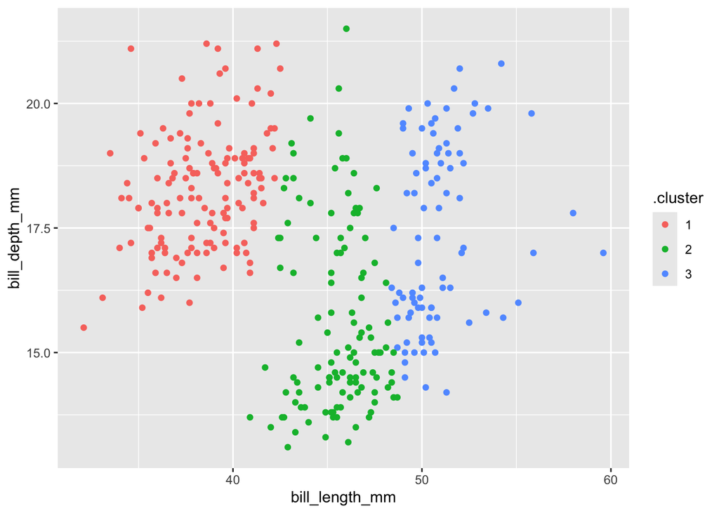

```r
data_prep <- penguins |>
  select(bill_length_mm, bill_depth_mm) |>
  remove_missing()

data_prep |>
  kmeans(centers = 3) |>
  augment(data_prep) |>
  ggplot() +
  aes(bill_length_mm, bill_depth_mm) +
  geom_point() +
  aes(color = .cluster)
```

```r
set_num_centers <- function(num_centers = 3){

  options(ggkmeans.num_centers = num_centers)

}


compute_panel_kmeans <- function(data, scales, centers = getOption("ggkmeans.num_centers", 3), seed = 1234){

  set.seed(seed)

  data_prep <- data |>
    mutate(row_id = row_number()) |>
    select(x, y) |>
    remove_missing()

  data_prep |>
  kmeans(centers = centers) |>
  augment(data_prep)

}


StatKmeans <- ggproto("StatKmeans", Stat,
                      compute_panel = compute_panel_kmeans,
                      default_aes = aes(color = after_stat(.cluster)))

#' @export
geom_kmeans <- make_constructor(GeomPoint, stat = StatKmeans)
```

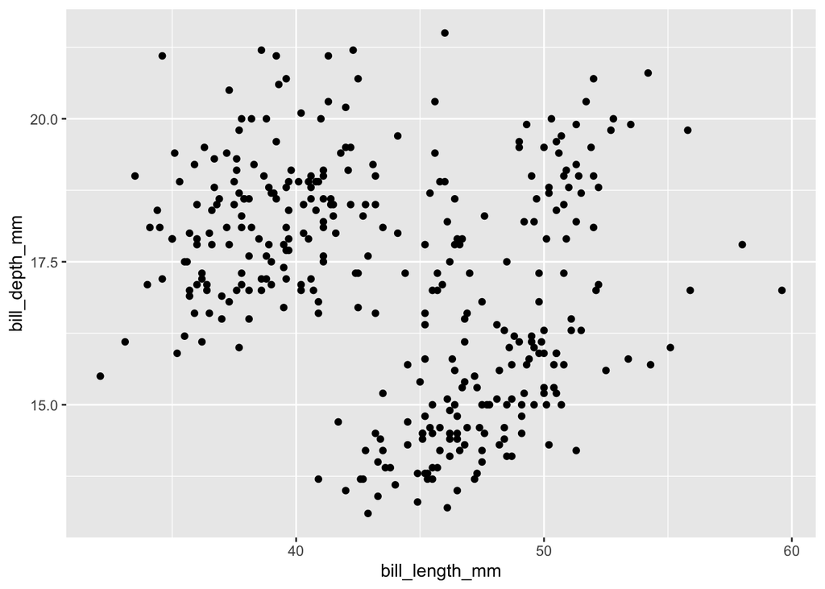

```r
penguins |>
  ggplot() +
  aes(bill_length_mm, bill_depth_mm) +
  geom_point()
```

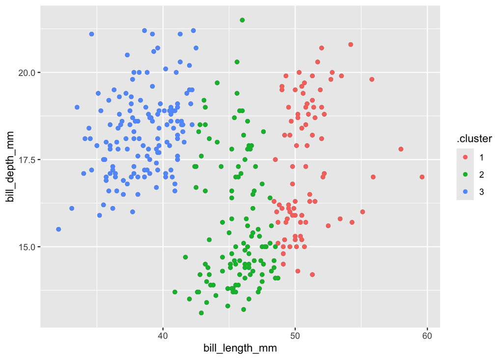

```r
last_plot() +
  geom_kmeans()
```

```r
compute_panel_kmeans_tidy <- function(data, scales, centers = getOption("ggkmeans.num_centers", 3), seed = 1234){

  set.seed(seed)

  data_prep <- data |>
    mutate(row_id = row_number()) |>
    select(x, y) |>
    remove_missing()

  data_prep |>
  kmeans(centers = centers) |>
  tidy() |>
  rename(.size = size)

}


StatKmeansCenters <- ggproto("StatKmeansCenters", Stat,
                      compute_panel = compute_panel_kmeans_tidy)

GeomPointX <- ggproto("GeomPointX", GeomPoint,
                      default_aes = GeomPoint$default_aes |>
                        modifyList(aes(shape = 13, size = 7),
                                   keep.null = T)
                      )

#' @export
geom_kmeans_center <- make_constructor(GeomPointX, stat = StatKmeansCenters)
```

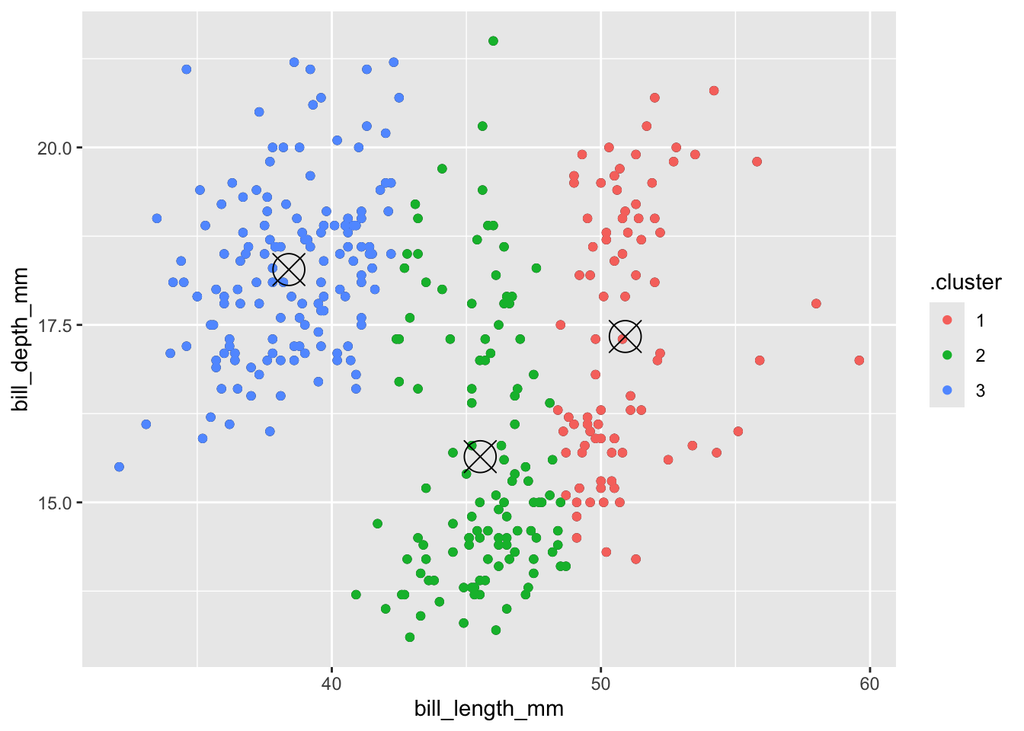

```r
last_plot() +
  geom_kmeans_center()
```

```r
compute_panel_kmeans_lengths <- function(data, scales,
                                         centers = getOption("ggkmeans.num_centers", 3), seed = 1234){

  set.seed(seed)

  data_prep <- data |>
    mutate(row_id = row_number()) |>
    select(x, y) |>
    remove_missing()

  kmeaned <- data_prep |>
    kmeans(centers = centers)

  points <- kmeaned |>
  augment(data_prep)

  kmeaned |>
  tidy() |>
  rename(.size = size) |>
  rename(.cluster = cluster) |>
  rename(xend = x, yend = y) |>
  right_join(points)

}


StatKmeansSegments <- ggproto("StatKmeansSegments", Stat,
                              compute_panel = compute_panel_kmeans_lengths,
                              default_aes = aes(color = after_stat(.cluster)))

GeomSegmentThin <- ggproto("GeomSegmentThin", GeomSegment,
                           default_aes = GeomSegment$default_aes |>
                             modifyList(aes(linewidth = .2, alpha = .5)))


#' @export
geom_kmeans_lengths <- make_constructor(GeomSegmentThin, stat = StatKmeansSegments)
```

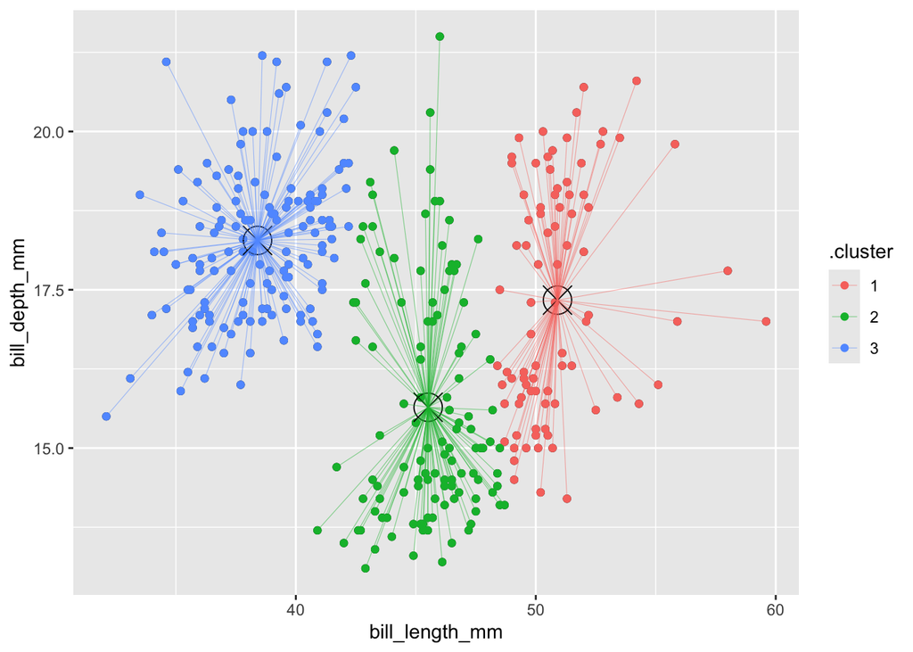

```r
last_plot() +
  geom_kmeans_lengths()
```

# Specifying different numbers of centers

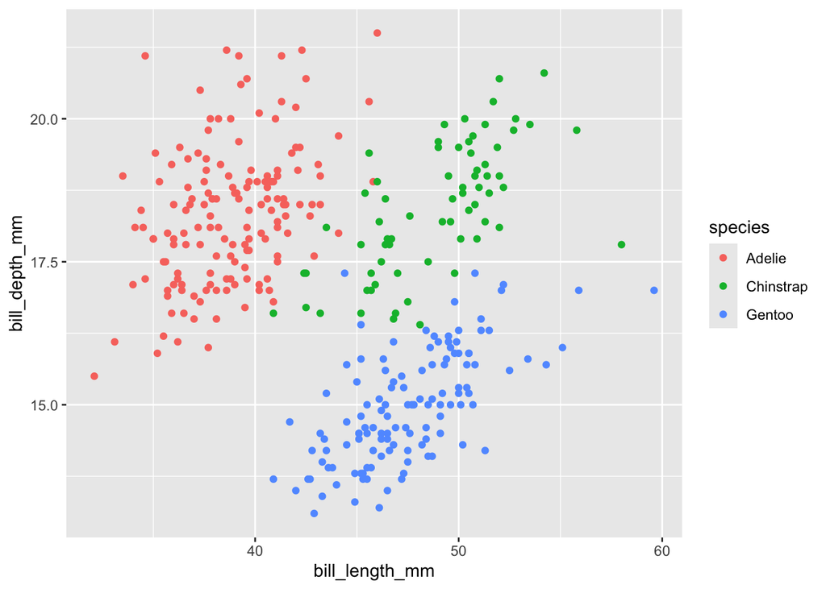

```r
penguins |>
  ggplot() +
  aes(bill_length_mm, bill_depth_mm) +
  geom_point() +
  aes(color = species)
```

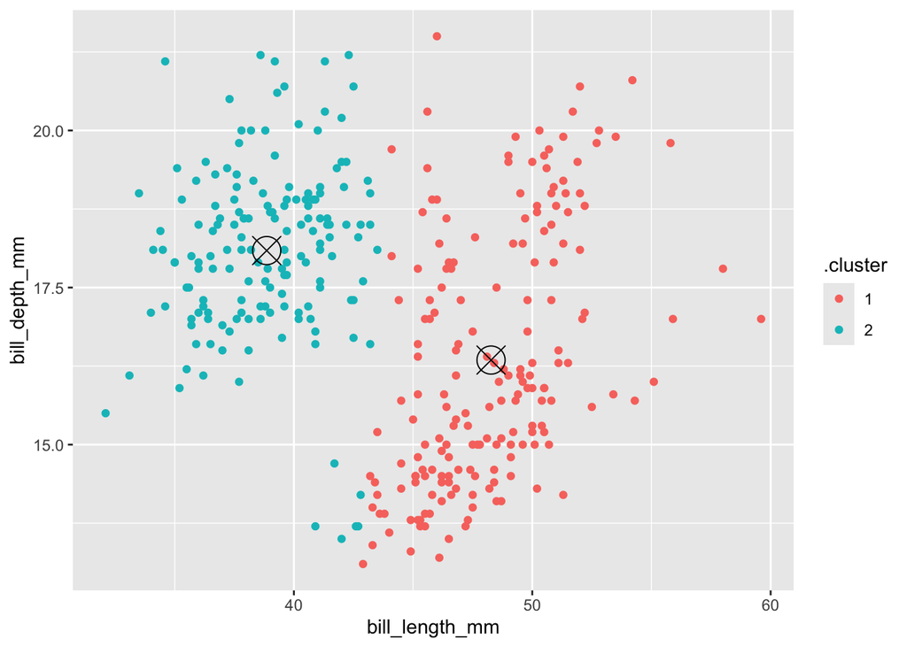

```r
set_num_centers(2)
penguins |>
  ggplot() +
  aes(bill_length_mm, bill_depth_mm) +
  geom_kmeans() +
  geom_kmeans_center()
```

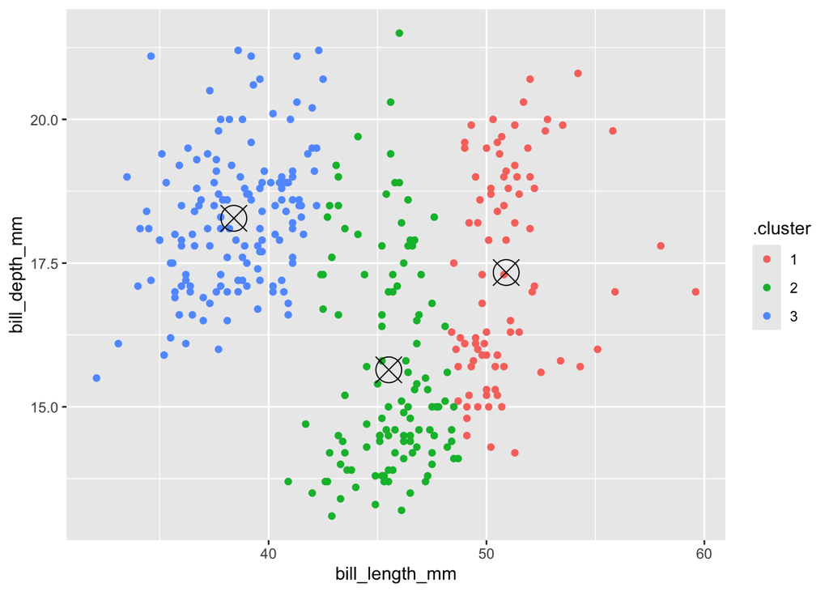

```r
set_num_centers(3)
last_plot()
```

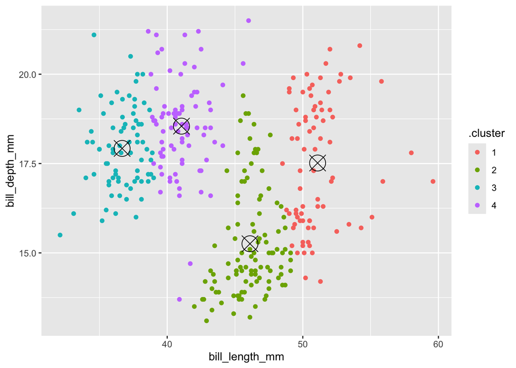

```r
set_num_centers(4)
last_plot()
```

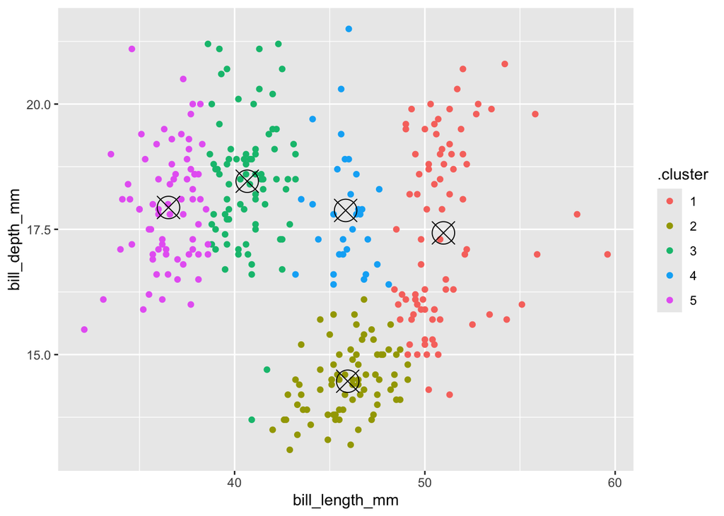

```r
set_num_centers(5)
last_plot()
```

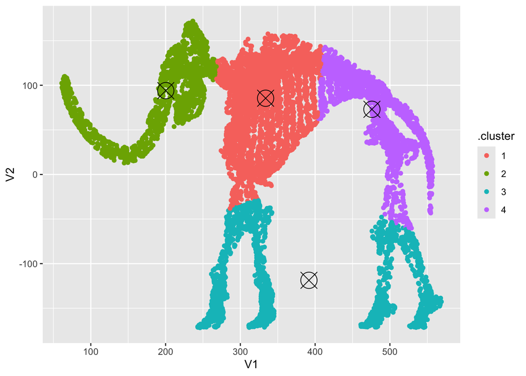

```r
PAIR_code_umap_mammoth_url <- "https://raw.githubusercontent.com/PAIR-code/understanding-umap/refs/heads/master/raw_data/mammoth_3d.json"

library(ggdims)



mammoth_df <- PAIR_code_umap_mammoth_url |>
  jsonlite::fromJSON() |>
  as.data.frame()


set_num_centers(4)

 mammoth_df |>
  ggplot() +
  aes(V1, V2) +
  geom_kmeans() +
  geom_kmeans_center()
```

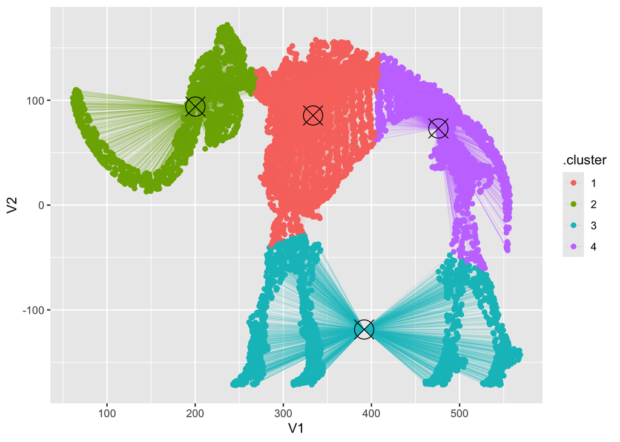

```r
mammoth_df |>
  ggplot() +
  aes(V1, V2) +
  geom_kmeans() +
  geom_kmeans_lengths(linewidth = .2, alpha = .2) +
  geom_kmeans_center()
```

```r
layer_three <- layer_data(i = 3)
```

[figure not shown]

```r
last_plot() +
  ggforce::geom_voronoi_segment(data = layer_three,  # geom_kmeans_partitian
                                aes(x = x,
                                    y = y)) +
  ggforce::geom_voronoi_tile(data = layer_three |> rename(.cluster = cluster),
                                aes(x = x,
                                    y = y,
                                    fill = .cluster))
```

```r
library(tidyverse)

ind_complete <- complete.cases(penguins)

penguins |>
  select(bill_len, bill_dep) |>
  filter(ind_complete) |>
  kmeans(centers = 4) |>
  broom::tidy()

penguins |>
  select(bill_len, bill_dep) |>
  # filter(ind_complete) |>
  kmeans(centers = 4) |>
  broom::augment(
    penguins |>
      filter(ind_complete)
    )
```

[output not shown]

## Closing remarks, Other Relevant Work, Caveats

```r
compute_group_means <- function(data, scales){

  data |>
    summarise(x = mean(x, rm.na = T),
              y = mean(y, rm.na = T))

}
```